# Notebook

notebook to Explore Conditional Probability using FACTS output  
by Praveen Kumar and Bob Kopp

Projecting sea level requires integrating contributions from Ice sheets, glaciers, ocean models, and population dynamics, accounting for emissions.

These frameworks exist mainly as Earth System Models, however,

1. they are computationally demanding.
2. often only offer single deterministic projections.

*A complementary approach* involves using emulators, Framework for Assessing Changes To Sea-level (**FACTS**) can be thought of as an emulator-based approach for probabilistic projections of sea-level.

- an assessment tool to help users understand how sea levels could respond to future climate variability.
- open-source sea-level projection software library.
- It is designed to emulate detailed, process-based analyses of individual sea-level contributions and coupled projections made with Earth System Models.

Within FACTS, Relative SL is obtained by aggregating probability distributions from individual drivers, including ice sheets, glaciers, land water storage, and sterodynamic processes.

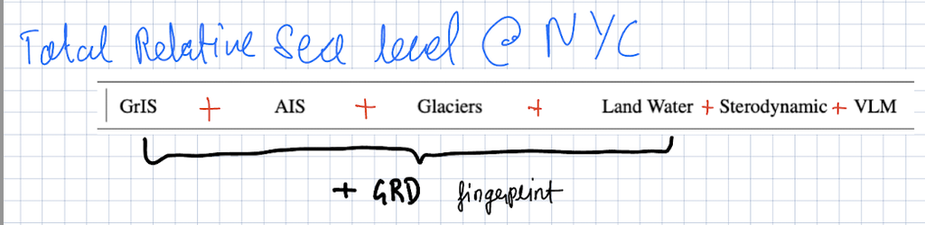

```
<IPython.core.display.Image object>
```

- **Sterodynamic** sea level is estimated based on the correlation between thermal expansion (derived from GSAT and OHC; FaIR) and local dynamic sea level in the CMIP6 multimodel ensemble.
- **VLM** long-term contributions from vertical land motion

**FACTS can be run conditional upon specified modeling assumptions.** and each assumption is called a workflow

[figure not shown]

```
<IPython.core.display.Image object>
```

Read Data:: *FACTS 1.1.1*

```
... Done
```

NYC total SL in 2100 conditional on

1. 2030 RSL observations TOTAL
2. 2030 GMSL observation TOTAL
3. 2030 Thermal Expansion
4. 2030 Sterodynamic observations
5. 2030 AIS component

Plot:: raw data / samples

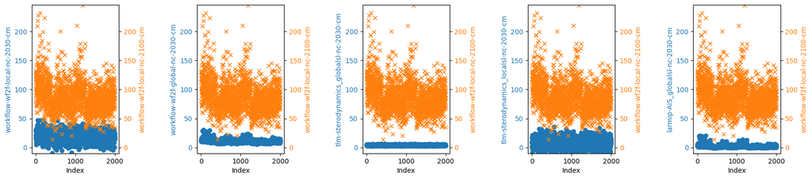

```
<Figure size 2000x400 with 10 Axes>
```

Plot:: Scatter

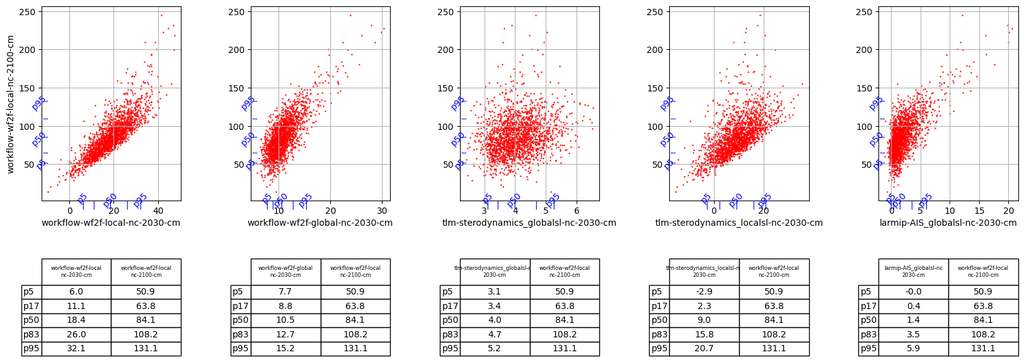

```
<Figure size 2000x400 with 5 Axes>
```

Compute:: KDE

KDE estimates the joint probability density function 𝑃(𝑋,𝑌) for the data.  
When you evaluate KDE on a grid of X and Y values, you get a matrix where each element represents the joint density at that specific (X, Y) point.  
density_values: This is the joint density estimate 𝑃 ( 𝑋 , 𝑌 ) , computed by evaluating the KDE on the entire grid of (Xgrid, Ygrid) points.  
After normalization, each column represents a probability distribution over Y, given a fixed X:  
normalized_density_values represents the entire conditional distribution matrix 𝑃 ( 𝑌 ∣ 𝑋 ) over all evaluated X values.

PLOT:: KDE

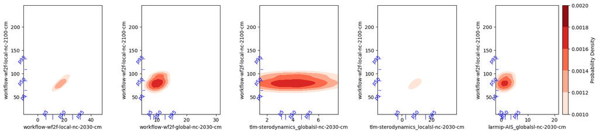

```
<Figure size 2000x400 with 6 Axes>
```

PLOT:: normalized KDE (conditional distributions.)

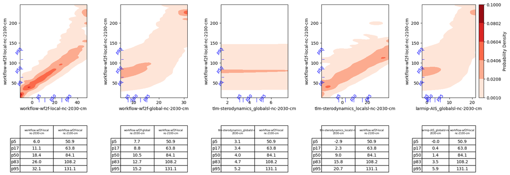

```
<Figure size 2000x400 with 6 Axes>
```

- percentiles are calculated from the original distribution.

Plot:: Constrain to percentile values.

Plot conditional distribution for specific X (5-95 percentile) .

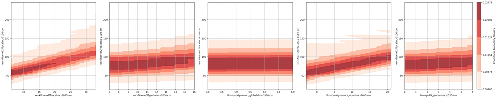

```
<Figure size 3000x600 with 6 Axes>
```

SCRATCH